# stream evaluation

jharner

April 8, 2015

## 6. Evaluating data stream clustering

### 6.1. Introduction

Evaluation of conventional clustering only measures how well the algorithm learns static structure in the data. Data streams often exhibit concept drift and it is important to evaluate how well the algorithm is able to adapt to these changes. The evaluation of data stream clustering is still in its infancy. `stream` can be used to evaluate clustering algorithms in terms of learning static structures and clustering dynamic streams.

### 6.2. Evaluating the learned static structure

Evaluation how well an algorithm is able to learn a static structure in the data is performed in stream via

```
evaluate(dsc, dsd, measure, n = 100, type = c("auto", "micro", "macro"), assign = "micro", assignmentMethod = c("auto", "model", "nn"), ...)
```

where dsc is the evaluated clustering. `n` data points are taken from `dsd` and used for evaluation. The points are assigned to the clusters in the clustering in `dsc` using `get_assignment()`. By default the points are assigned to micro-clusters, but it is also possible to assign them to macro-cluster centers instead (`assign = "macro"`). New points can be assigned to clusters by the rule used in the clustering algorithm (`assignmentMethod = "model"`) or using nearest- neighbor assignment (`"nn"`). If the assignment method is set to `"auto"` then model assignment is used when available and otherwise nearest-neighbor assignment is used. The initial assignments are aggregated to the level specified in type. For example, for a macro-clustering, the initial assignments will be made by default to micro-clusters and then these assignments will be translated into macro-cluster assignments using the micro-to macro-cluster relationships stored in the clustering and available via `microToMacro()`. This separation between assignment and evaluation type is especially important for data with non-spherical clusters where micro-clusters are linked together in chains produced by a macro-clustering algorithm based on hierarchical clustering with single-link or reachability. Finally, the evaluation measure specified in measure is calculated. Several measures can be specified as a vector of character strings.

Clustering evaluation measures can be categorized into internal and external cluster validity measures. Internal measures evaluate properties of the clustering. A simple measure to evaluate the compactness of (spherical) clusters in a clustering is the within-cluster sum of squares, i.e., the sum of squared distances between each data point and the center of its cluster (method `"SSQ"`). External measures use the ground truth (i.e., true partition of the data into groups) to evaluate the agreement of the partition created by the clustering algorithm with a known true partition.

Measures currently available for `evaluate()` (method name are under quotation marks and the package that implements the evaluation measure is shown in parentheses) include:

- Information items

> “numMicroClusters” Number of micro-clusters  
> “numMacroClusters” Number of macro-clusters  
> “numClasses” Number of classes (i.e., groups in the ground truth)
- Internal evaluation measures

> “SSQ” Within cluster sum of squares (actual noise points identified by the clustering algorithm are excluded)  
> “silhouette” Average silhouette width (actual noise points identified by the clustering algorithm are excluded) (cluster)  
> “average.between” Average distance between clusters (fpc)  
> “average.within” Average distance within clusters (fpc)  
> “max.diameter” Maximum cluster diameter (fpc)  
> “min.separation” Minimum cluster separation (fpc)  
> “ave.within.cluster.ss” a generalization of the within-clusters sum of squares (half the sum of the within-cluster squared dissimilarities divided by the cluster size) (fpc)  
> “g2” Goodman and Kruskal’s Gamma coefficient (fpc)  
> “pearsongamma” Correlation between distances and a 0-1-vector where 0 means same cluster, 1 means different clusters (fpc)  
> “dunn” Dunn index (minimum separation over maximum diameter) (fpc)  
> “dunn2” Minimum average dissimilarity between two cluster over maximum average within-cluster dissimilarity (fpc)  
> “entropy” entropy of the distribution of cluster memberships (fpc)  
> “wb.ratio” average.within over average.between (fpc)
- External evaluation measures

$\mbox{precision} = \frac{TP}{TP + FP}$  
$\mbox{recall} = \frac{TP}{TP + FN}$

The F1 measure is the harmonic mean of precision and recall.

> “purity” Average purity of clusters. The purity of each cluster is the proportion of the points of the majority true group assigned to it.  
> “Euclidean” Euclidean dissimilarity of the memberships (clue), “Manhattan” Manhattan dissimilarity of the memberships (clue)  
> “Rand” Rand index (clue)  
> “cRand” Rand index corrected for chance (clue)  
> “NMI” Normalized Mutual Information (clue)  
> “KP” Katz-Powell index (clue)  
> “angle” Maximal cosine of the angle between the agreements (clue) “diag” Maximal co-classification rate (clue)  
> “FM” Fowlkes and Mallows’s index (clue)  
> “Jaccard” Jaccard index (clue)  
> “PS” Prediction Strength (clue)  
> “vi” Variation of Information (VI) index (fpc)

### 6.3. Evaluating clustering of dynamic streams

For dynamic data streams it is important to evaluate how well the clustering algorithm is able to adapt to the changing cluster structure. For data stream clustering, a horizon is defined as a number of data points. The data stream is split into consecutive horizons and after clustering all the data in a horizon the average sum of squares is reported as an internal measure of cluster quality. Here for each (micro-) cluster the dominant true cluster label is determined and the proportion of points with the dominant label is averaged over all clusters. Algorithms which can better adapt to the changing stream will achieve better evaluation values. This evaluation strategy is implemented in `stream` as function `evaluate_cluster()`. It shares most parameters with `evaluate()` and all evaluation measures for `evaluate()` described above can be used.

### 6.4. Example: Evaluating clustering results

In this example we will show how to calculate evaluation measures, first on a stream without concept drift and then on an evolving stream. First, we prepare a data stream and create a clustering.

```r
library("stream")
stream <- DSD_Gaussians(k = 3, d = 2, noise = .05)
dstream <- DSC_DStream(gridsize = .1)
update(dstream, stream, n = 500)
```

The `evaluate()` function takes a `DSC` object containing a clustering and a DSD object with evaluation data to compute several quality measures for clustering.

```r
evaluate(dstream, stream,  measure=c("numMicro","numMacro","purity","crand", "SSQ"), n = 100)
```

```
## Evaluation results for micro-clusters.
## Points were assigned to micro-clusters.
##
## numMicroClusters numMacroClusters           purity            cRand
##       6.00000000       2.00000000       0.89552239       0.05008794
##              SSQ
##       7.32782196
```

We use only a small number of points for evaluation since calculating some measures is computational quite expensive. Individual measures can be calculated using the `measure` argument.

```r
evaluate(dstream, stream, measure = c("purity", "crand"), n = 500)
```

```
## Evaluation results for micro-clusters.
## Points were assigned to micro-clusters.
##
##    purity     cRand
## 0.9312839 0.1766745
```

Note that this second call of `evaluate()` uses a new and larger set of 500 evaluation data points from the stream and thus the results may vary slightly from the first call. Purity of the micro-clusters is high since each micro-cluster only covers points from the same true cluster, however, the corrected Rand index is low because several micro-clusters split the points from each true cluster. We will see in one of the following examples that reclustering will improve the corrected Rand index.

To evaluate how well a clustering algorithm can adapt to an evolving data stream, stream provides `evaluate_cluster()`. We define an evaluation horizon as a number of data points. Each data point in the horizon is used for clustering and then it is evaluated how well the point’s cluster assignment fits into the clustering (internal evaluation) or agrees with the known true clustering (external evaluation). Average evaluation measures for each horizon are returned.

```r
stream <- DSD_Benchmark(1)
dstream <- DSC_DStream(gridsize = .05, lambda = .01)
ev <- evaluate_cluster(dstream, stream, measure = c("numMicroClusters", "purity"),
                       n = 5000, horizon = 100)
head(ev)
```

```
##      points numMicroClusters purity
## [1,]    100                8      1
## [2,]    200               12      1
## [3,]    300               13      1
## [4,]    400               13      1
## [5,]    500                9      1
## [6,]    600               13      1
```

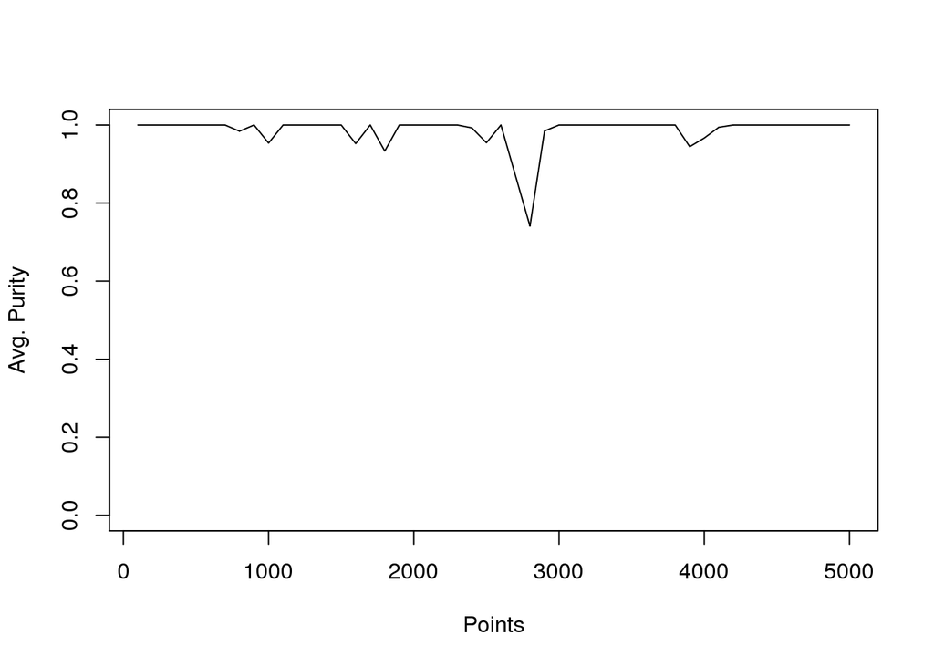

```r
plot(ev[ , "points"], ev[ , "purity"], type = "l", ylim = c(0, 1),
     ylab = "Avg. Purity", xlab = "Points")
```

The plot shows the development of the average micro-cluster purity (how well each micro- cluster only represents points of a single group in the ground truth) over 5000 data points in the data stream. Purity drops before point 3000 significantly, because the two true clusters overlap for a short period of time.

To analyze the clustering process, we can visualize the clustering using `animate_cluster()`. To recreate the previous experiment, we reset the data stream and create a new empty clustering.

```
reset_stream(stream)
dstream <- DSC_DStream(gridsize = .05, lambda = .01)
r <- animate_cluster(dstream, stream, n = 5000, horizon = 100,
                     evaluationMeasure = "purity", xlim = c(0, 1), ylim = c(0, 1))
```

### 6.5. Example: Evaluating reclustered DSC objects

This example shows how to recluster a DSC object after creating it and performing evaluation on the macro clusters. First we create data, a DSC micro-clustering object and run the clustering algorithm.

```r
stream <- DSD_Gaussians(k = 3, d = 2, noise = .05)
dstream <- DSC_DStream(gridsize = .05, Cm = 1.5)
update(dstream, stream, n = 1000)
dstream
```

```
## D-Stream
## Class: DSC_DStream, DSC_Micro, DSC_R, DSC
## Number of micro-clusters: 72
## Number of macro-clusters: 2
```

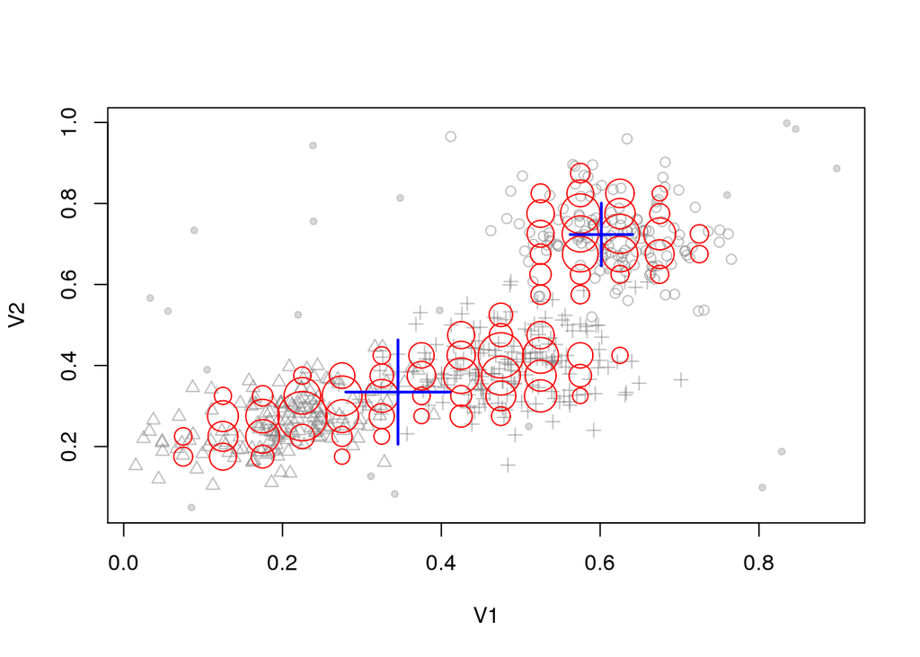

```r
plot(dstream, stream, type = "both")
```

```r
km <- DSC_Kmeans(k = 3, weighted = TRUE)
recluster(km, dstream)
km
```

```
## k-Means (weighted)
## Class: DSC_Kmeans, DSC_Macro, DSC_R, DSC
## Number of micro-clusters: 72
## Number of macro-clusters: 3
```

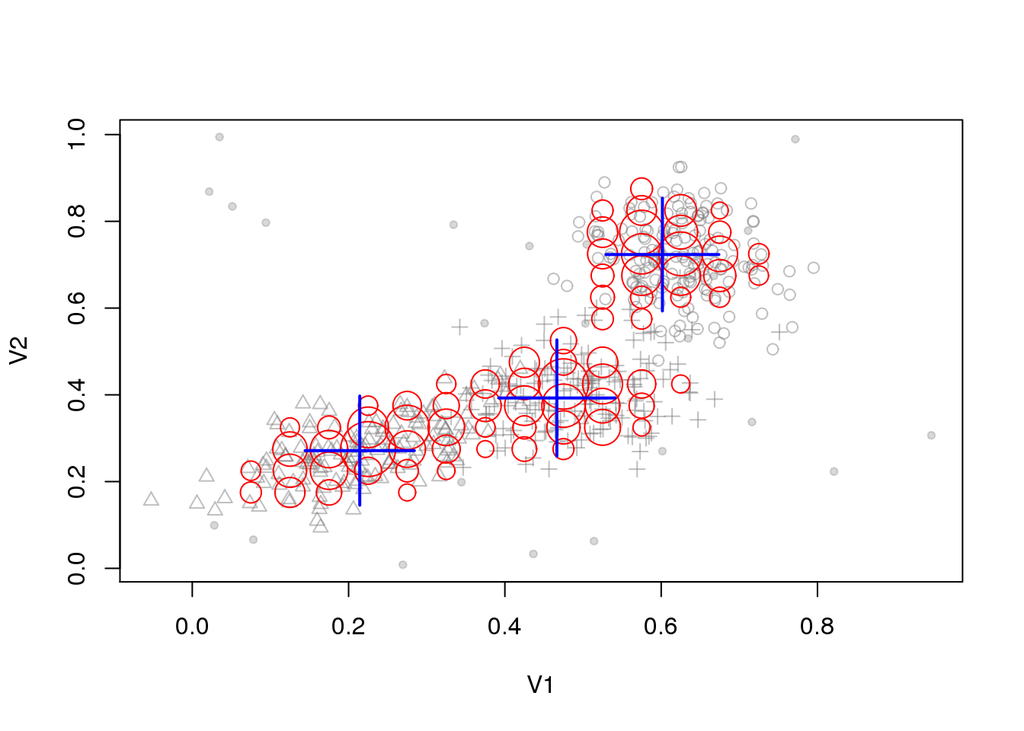

```r
plot(km, stream, type = "both")
```

This plot shows that weighted k-means on the micro-clusters produces by D-Stream separated the three clusters correctly.

Evaluation on a macro-clustering model automatically uses the macro-clusters. For evaluation, `n` new data points are requested from the data stream and each is assigned to its nearest micro-cluster. This assignment is translated into macro-cluster assignments and evaluated using the ground truth provided by the data stream generator.

```r
evaluate(km, stream, measure = c("purity", "crand", "SSQ"), n = 1000)
```

```
## Evaluation results for macro-clusters.
## Points were assigned to micro-clusters.
##
##     purity      cRand        SSQ
##  0.9027648  0.7912850 15.6656532
```

Alternatively, the new data points can also be directly assigned to the closest macro-cluster.

```r
evaluate(km, stream, c(measure = "purity", "crand", "SSQ"), n = 1000,
            assign = "macro")
```

```
## Evaluation results for macro-clusters.
## Points were assigned to macro-clusters.
##
##     purity      cRand        SSQ
##  0.9011402  0.7871620 14.8158365
```

```r
points <- get_points(stream, n = 100)
assignment <- get_assignment(dstream, points, type = "macro")
assignment
```

```
##   52   22    1   17    6    9   51   55   54   26 <NA>   72   23   27   43
##    2    2    2    1    1    2    2    2    2    1   NA    2    1    1    2
##   46   70 <NA>   54   47   70   16   55   17   33 <NA>   11   29 <NA>    7
##    2    2   NA    2    2    2    1    2    1    1   NA    2    1   NA    1
##   50   66   34   19   72   64   24   36   32    6   24   24   71 <NA> <NA>
##    2    2    1    1    2    2    1    2    1    1    1    1    2   NA   NA
##   40 <NA>   27 <NA>   37   46   37   69   42   63 <NA>   44   24 <NA>   14
##    2   NA    1   NA    2    2    2    2    2    2   NA    2    1   NA    1
##   55   26    9   20   50    5   34 <NA>   71   72   72   13   62 <NA> <NA>
##    2    1    2    2    2    1    1   NA    2    2    2    1    2   NA   NA
## <NA>   10 <NA>    9   16 <NA>   44   64 <NA>   16   70   25   70   26   39
##   NA    2   NA    2    1   NA    2    2   NA    1    2    1    2    1    2
##   61   62   45   38 <NA>    4   55 <NA>   36   60
##    2    2    2    2   NA    1    2   NA    2    2
## attr(,"method")
## [1] "model"
```

Note that D-Stream uses a grid for assignment and that points which do not fall inside a dense (or connected transitional) cell are not assigned to a cluster represented by a value of `NA`. For the following silhouette calculation we replace the NAs with 0 to make the unassigned (noise) points its own cluster. Note that the silhouette is only calculated for a small number of points and not the whole stream.

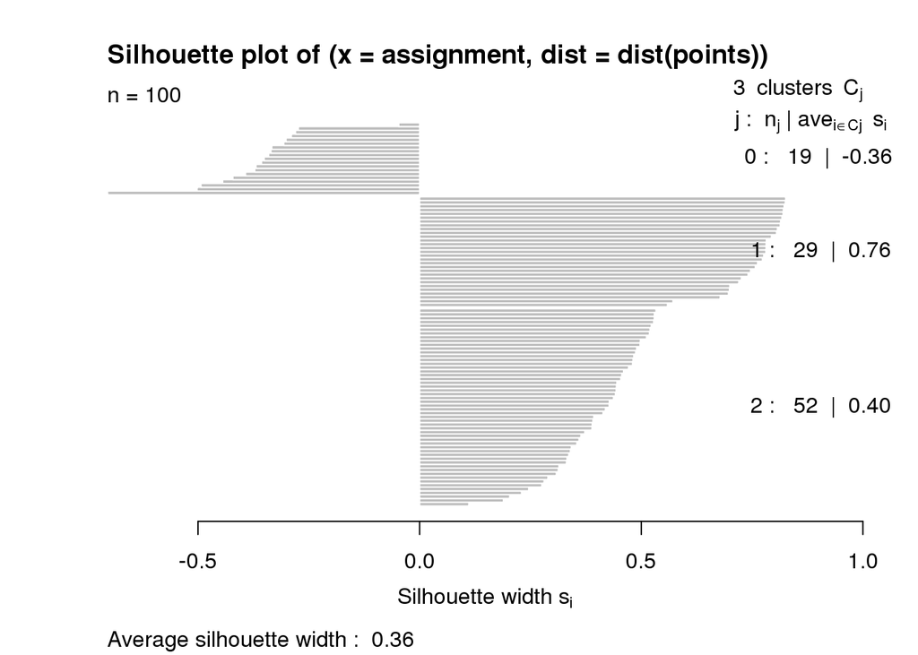

```r
assignment[is.na(assignment)] <- 0L
library("cluster")
plot(silhouette(assignment, dist = dist(points)))
```